# GEDI Presentation

Sam Watson, Amanda Payton, Wenqu Chen

May 4, 2020

## Project Goals

The goals of this project are:

- Develop R code to download GEDI data for the study area
- Determine the relationship between the study area zones and GEDI metrics
- Determine the relationship between the distance from roads and GEDI metrics

## Study Area

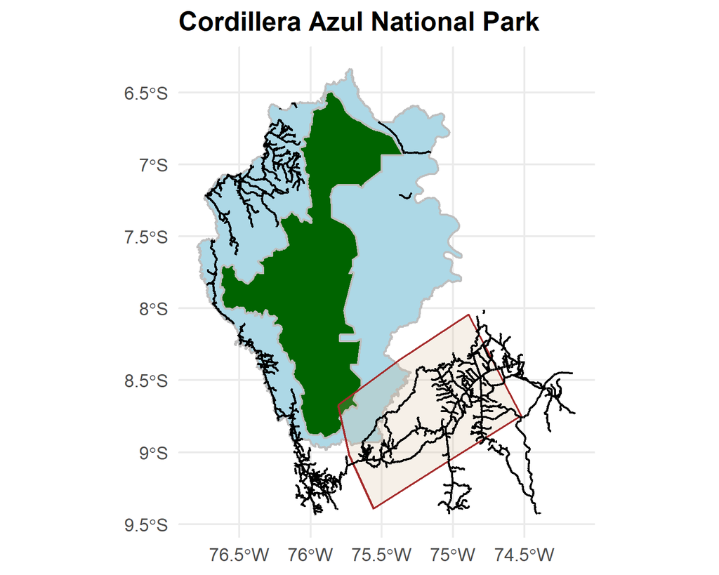

## Introduction to GEDI

- full waveform LiDAR instrument launched December 5th, 2018
- highest resolution and densest sampling of any lidar ever put into orbit
- four types of vegetation structure information can be extracted:
  - surface topography
  - canopy height metrics
  - canopy cover metrics
  - vertical structure metrics

[figure not shown]

## Sample of PAI

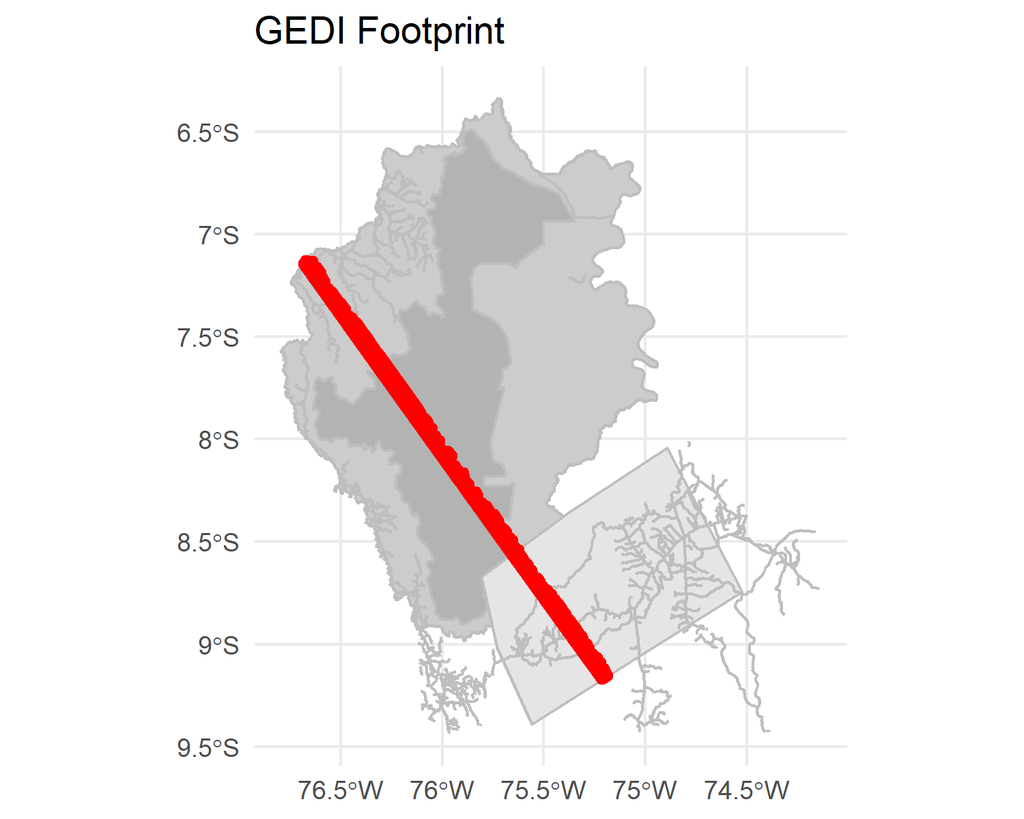

```
##    Min. 1st Qu.  Median    Mean 3rd Qu.    Max.    NA's
##   0.001   1.438   2.684   2.663   3.790   7.982   22193
```

## GEDI Metrics

- Plant Area Index
- Relative Height

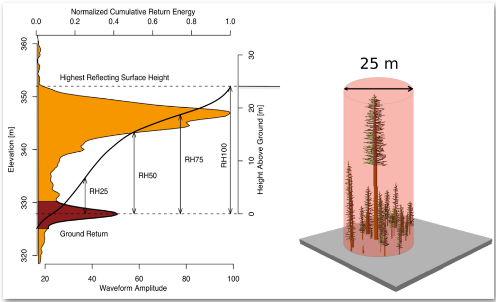

(Image courtesty of https://gedi.umd.edu/data/products/)

## Results

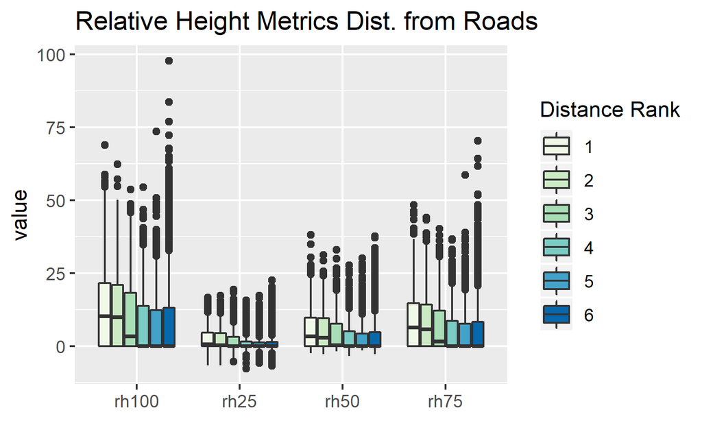

## Results

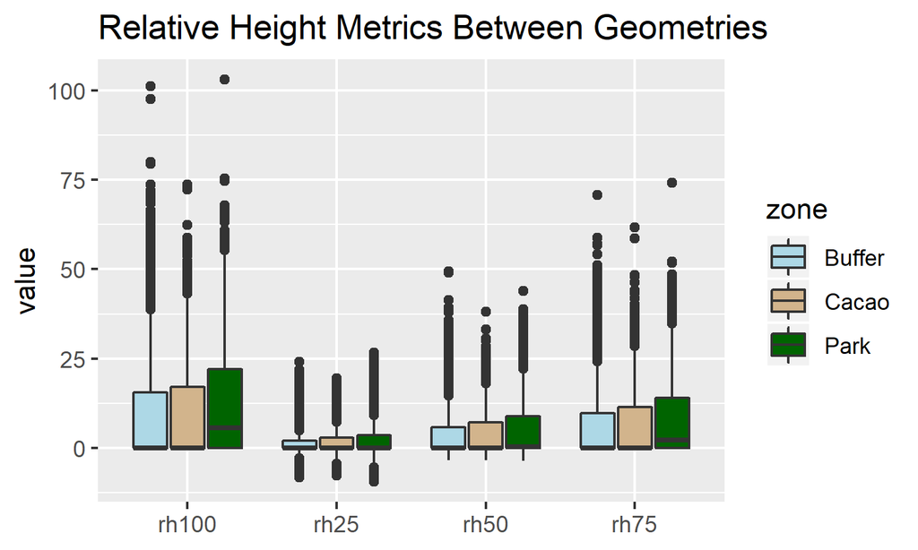

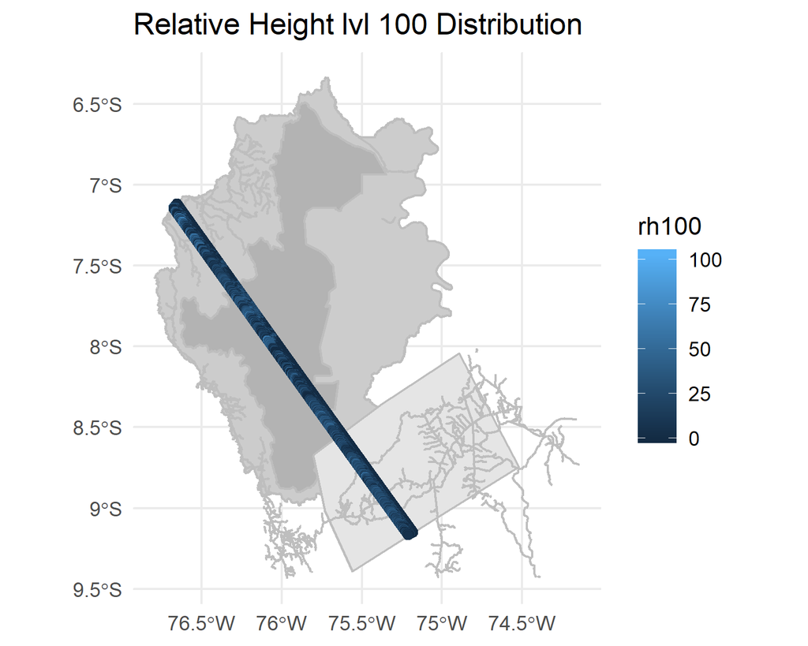